# Diving deep: brain capacity

Date: May 24, 2020

Table of contents:

- Basic stats
- Biological brains comparisons
- Thermal and power limits
- Training effectiveness
- Case study: AlexNet from 2012
- What should we hope for in the future?

Today, I hope to be able to dissect some of the performance numbers of various current AI systems and compare that to the brain, to hopefully give you a better understanding of what scale are we at right now and what we should expect moving forward.

## Basic stats

[Common estimates](https://towardsdatascience.com/the-differences-between-artificial-and-biological-neural-networks-a8b46db828b7) put the brain at 86 billion neurons and 100-1000 trillion synapses. A specific neuron can't fire instantaneously fast. It has a cooldown period and the fastest it can fire is around 200 times/s. The speed of a signal is 0.61 m/s for bare synapses (connection between neurons), and 119 m/s for synapses with myelin sheath. For those who don't know, it's this thing:

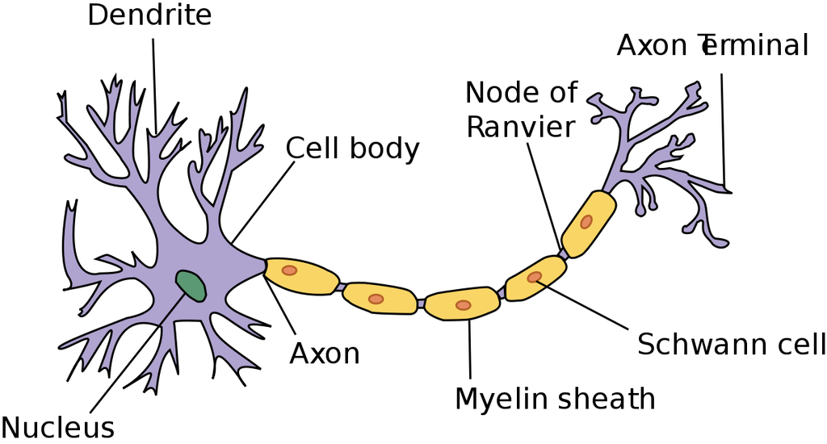

Think of the electrical signal as a simple water wave (but in reality, it's a chemical/ion gradient wave). For vanilla synapses, the water wave has to travel along the synapses slowly, but with the sheath, it can jump from 1 node of ranvier to the next right away, so that explains the 200 times boost in velocity. The brain also consumes 20-25% of the energy a human produces. That specifically amounts to 20 W, barely powerful enough to power a light bulb.

Each neuron is around $100\mu m$, or $0.1mm$ in diameter. Men usually have a brain volume of $1260cm^3$ and women of $1130cm^3$. $1000cm^3$ is actually 1 liter btw. As $\sqrt[3]{1000}=10cm$, we can consider the brain is a 10cm cube of neurons. $10cm = 100mm$, and so the brain is $\frac{100mm}{0.1mm} = 1000$ times larger than neurons in length. That means it can roughly contain $1000^3=10^9$ (a billion) neurons. So we're in the ballpark of the 86 billion neuron estimates. The difference is due to the increased brain volume and smaller neuron size.

How about artifical networks? Let's bring a damn simple network from the [Unboxing the blackbox: basics](http://blackbox.nn.157239n.com/basics) post over:

```python
import torch
import numpy as np
import matplotlib.pyplot as plt
import torch.nn as nn
import pandas as pd

import torchvision.datasets as datasets
import torchvision
import torch.optim as optim
import time
```

```
dl has 60000 images, dl_test has 10000
```

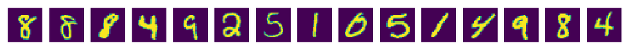

```python
dl = torch.utils.data.DataLoader(datasets.MNIST("datasets/", download=True,
                                 transform=torchvision.transforms.Compose([
                                     torchvision.transforms.ToTensor(),
                                     torchvision.transforms.Normalize((0.1307,), (0.3081,))
                                 ])), batch_size=1000, shuffle=True)
dl_test = torch.utils.data.DataLoader(datasets.MNIST("datasets/", download=True, train=False,
                                 transform=torchvision.transforms.Compose([
                                     torchvision.transforms.ToTensor(),
                                     torchvision.transforms.Normalize((0.1307,), (0.3081,))
                                 ])), batch_size=100, shuffle=True)
print(f"dl has {len(dl)*1000} images, dl_test has {len(dl_test)*100}")
plt.figure(num=None, figsize=(10, 6), dpi=350)
imgs, labels = next(iter(dl))
for i in range(15): plt.subplot(1, 15, i+1); plt.imshow(imgs[i][0]); plt.axis("off")
```

```
Takes 18 seconds to train
```

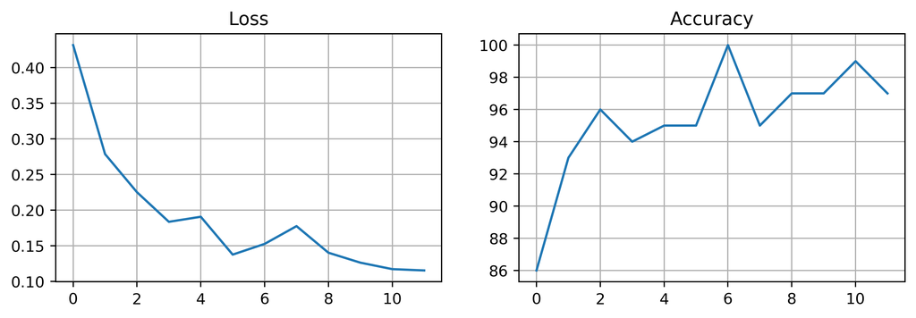

```python
class BuiltInNet(nn.Module):
    def __init__(self):
        super().__init__()
        self.fc1 = nn.Linear(28 * 28, 100); self.fc2 = nn.Linear(100, 10); self.relu = nn.ReLU()
    def forward(self, x): return self.fc2(self.relu(self.fc1(x)))
    def train(self, epochs):
        optimizer, lossFunction = optim.Adam(self.parameters(), 0.01), nn.CrossEntropyLoss()
        count, losses, accuracies = 0, [], []
        for epoch in range(epochs):
            for imgs, labels in dl:
                batchSize = len(labels); output = self(imgs.view(-1, 28*28).cuda())
                loss = lossFunction(output, labels.cuda())
                loss.backward(); optimizer.step(); optimizer.zero_grad(); count += 1
                if count % 10 == 0:
                    losses.append(loss.item()); test_imgs, test_labels = next(iter(dl_test))
                    output = self(test_imgs.cuda().view(-1, 28*28))
                    accuracies.append((torch.argmax(output, dim=1) == test_labels.cuda()).sum())
        return torch.Tensor(losses), torch.Tensor(accuracies)
net = BuiltInNet().cuda(); beginTime = time.time(); losses, accuracies = net.train(2)
print(f"Takes {int(time.time()-beginTime)} seconds to train")
plt.figure(num=None, figsize=(10, 3), dpi=350)
plt.subplot(1, 2, 1); plt.grid(True); plt.plot(losses); plt.title("Loss")
plt.subplot(1, 2, 2); plt.grid(True); plt.plot(accuracies); plt.title("Accuracy"); pass
```

```python
print(f"fc1, weight: {net.fc1.weight.shape}, bias: {net.fc1.bias.shape}")
print(f"fc2, weight: {net.fc2.weight.shape}, bias: {net.fc2.bias.shape}")
```

```
fc1, weight: torch.Size([100, 784]), bias: torch.Size([100])
fc2, weight: torch.Size([10, 100]), bias: torch.Size([10])
```

This simple network has $100 * 784 + 100 + 10 * 100 + 10 = 79510$ weights and there are $100 + 10 = 110$ weight outputs. In human brains, each weight can be thought of as a synapse, and each activation/weight outputs can be thought of a neuron. This is sort of subjective, because I could have counted not only the weight's output, but also the ReLU's output, in which case there will be $100 + 100 + 10 + 10 = 220$ activations. However, the representation of a neuron is that it does the summation and the activation all in 1 spot, so we will go with 110 activations/neurons instead.

So how more powerful our brain is to this network? It has $\frac{86\cdot 10^9}{110}=781$ million more neurons and $\frac{500\cdot10^{12}}{79510}=6.3$ billion more synapses. Our network is horrendously overpowered by our brains.

## Biological brains comparisons

Let's try a [few different animals](https://en.wikipedia.org/wiki/List_of_animals_by_number_of_neurons), shall we?

| Species | Neurons | Times simple network |
| --- | --- | --- |
| Human | 86 billion | 781 million |
| Chimpanzee | 28 billion | 255 million |
| Cow | 3 billion | 27 million |
| Dog | 630 million | 5.7 million |
| Mouse | 70 million | 636 thousand |
| Cockroach | 1 million | 9.1 thousand |
| Ant | 250 thousand | 2.3 thousand |
| Snail | 11 thousand | 100 |
| Worm (C.elegans) | 302 | 2.7 |

Let's try to take something that's more capable. [Resnet architecture](https://arxiv.org/pdf/1512.03385.pdf) is pretty standard nowadays for a complex task, and pretty usable too. It has several flavors, but the middle tier is resnet 50, with 25.6 million parameters/weights.

Note that synapses numbers are hard to come by, so I did a simple model. Let's assume a brain as $n$ neurons, and each neuron connects with $a$ other neurons. Then the total amount of connections will be $\frac{n\cdot a}{2}$. But it's realistic to model $a$ as being dependent to $n$, because if the total amount of neurons were to drop, each neuron will realistically have lower amounts of connections. Let's make $a(n) = \alpha\cdot n$. But, this seems to overly correct the number, as $\#connections=\frac{\alpha}{2}\cdot n^2$, so let's have $\#connections=\alpha\cdot n^\beta$ instead. Assuming $\alpha$ and $\beta$ is the same for all species, we pick them so that the final number of weights are reasonable for all species. I messed around with the numbers so that they look right, and picked $\alpha = 0.246; \beta = 1.4$. Now we can obtain the rough number of weights estimates for all species:

| Species | Weights | Times simple network | Times resnet 50 |
| --- | --- | --- | --- |
| Human | 500 trillion | 6.3 billion | 19.5 million |
| Chimpanzee | 103 trillion | 1.3 billion | 4.1 million |
| Cow | 4.6 trillion | 57 million | 177 thousand |
| Dog | 512 billion | 6.4 million | 20 thousand |
| Mouse | 23 billion | 297 thousand | 923 |
| Cockroach | 61 million | 776 | 2.4 |
| Ant | 8.9 million | 111 | 0 |
| Snail | 112 thousand | 1.4 | 0 |
| Worm (C.elegans) | 729 | 0 | 0 |

Again, the $\#connections=\alpha\cdot n^\beta$ is just a rough estimate, which can be wrong, but I don't think we're off by an order of magnitude on any species though, and we just want the overall scale to get a feeling here.

Okay, so it's pretty clear that our networks are no where near the raw capability of biology right now. Let's assume a human brain is actually just a simple feed forward network with 500 trillion weights. This means on each forward pass, our brain calculates 500 trillion floating point operations (i.e multiplying 2 real numbers 500 trillion times). Neurons can also fire 200 times a second, but our brains certainly don't fire all 500 trillion neurons at once, and neurons can only do around 10 firings in 1 second sustainably, so let's ignore that. We can dive in this topic for the whole day and we still won't have exact numbers, but [other estimates](https://www.merkle.com/brainLimits.html) have it from $10^{13}$ to $10^{16}$ operations per second, so our calculation is close enough (500 trillion = $5\cdot10^{14}$) and we can move on.

What is the state of the art consumer CPU? Intel's [core i9](https://software.intel.com/content/www/us/en/develop/articles/raw-compute-power-of-new-intel-core-i9-processor-based-systems-enables-extreme-megatasking.html)'s performance is **1.3 teraflops**, or 1.3 trillion floating point operations every second. That's crazy speed, but still a hundredth of our brain.

NVidia's TITAN RTX graphics card, which is arguably the fastest GPU on the market that regular people can actually buy, can do **24-32 teraflops** with half-precision floating point numbers (16 bit float). It's certainly better, but still 18 times less performance than our brain.

The only consumer-ish product I can think of that is faster than that is Tesla's [full self driving chip](https://www.youtube.com/watch?v=Ucp0TTmvqOE):

[figure not shown]

This can do a whopping **144 teraflops**. This is on par with the lower end of human brains, so it's pretty exciting that we've gone this far.

## Thermal and power limits

Let's now look at thermal limits and power consumption.

The brain is so, so much more efficient than computers we have today. It consumes 20W of power, or roughly 20% of the entire body. NVidia's TITAN RTX's power consumption is 280W ($\frac{280}{20}\cdot\frac{500}{32}=218$ times more energy), and Tesla's FSD chip's power consumption is 15W ($\frac{15}{20}\cdot\frac{500}{144}=2.6$ times more energy). We're getting there, but may be around 2 more years we will have computers that have the same performance in everything as the brain does.

The numbers above have lots of leeway, and I have seen multiple estimates that contradict each other. However, that [Tesla autonomy day event](https://www.youtube.com/watch?v=Ucp0TTmvqOE) includes very, very interesting numbers at 1 hour 26 minute mark:

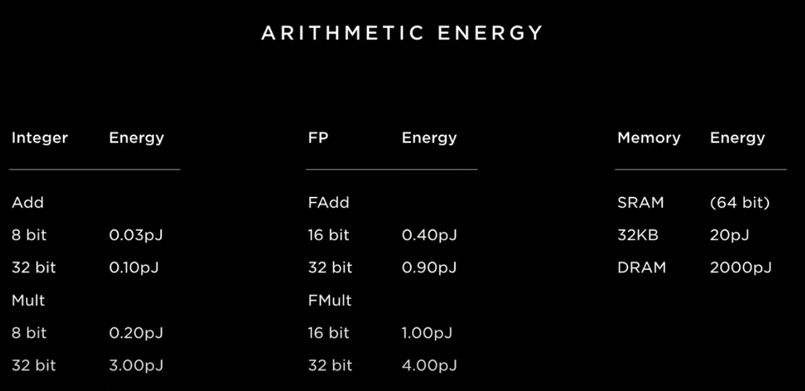

The brain's power estimate (sources: [1](https://www.amazon.com/Technologies-Singularity-Guru-Pada-Chattopadhyay-ebook/dp/B07DC8YXG8), [2](https://www.mathworks.com/academia/books/introduction-to-neural-networks-using-matlab-sivanandam.html), [3](https://www.merkle.com/brainLimits.html)) is around $10^{-16}J/op\cdot s$, while normal CPU power is around $10^{-6}J/op\cdot s$. On that slide, they reference Mark Horowitz's ["Computing's Energy Problems (and what we can do about it)" presentation](https://eecs.oregonstate.edu/research/vlsi/teaching/ECE471_WIN15/mark_horowitz_ISSCC_2014.pdf), which has more details if you want to dig in more. The next slide is this:

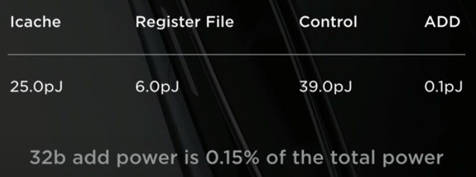

Note that this is only the case for 45nm technology, and we're now at 7-10nm technology (2020), but those numbers should give us a rough estimate.

This is just to demonstrate that the actual CPU architectures have lots of overhead, so much so that the actual calculation takes 0.15% of the total power. Our brains don't have to deal with as much overhead as that, so it's expected to be more power efficient. For integer arithmetic, Tesla chose to do 32 bit integers, costing $0.1pJ=10^{-13}J$ of energy for each operation. So once again, coming from another angle, it seems like we are approaching single human brains level, and fast.

Again, these numbers move around a lot for the brain, as we still don't entirely understand how it works just yet, so there are lots of different interpretations for the actual brain performance, but these numbers all agree within 1.5 orders of magnitude, so I think it's good enough to have a feel of what's going on.

If exponential improvement continues, when will we reach all human brains?

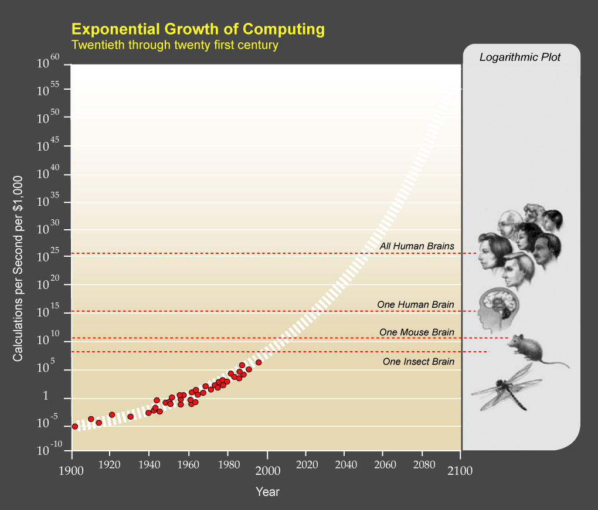

Will this trend ever end? Of course. The [absolute upper limit](https://www.youtube.com/watch?v=jv2H9fp9dT8) allowed by current understanding of physics is $10^{50}$ calculations per second. Tesla's FSD chip is only at $10^{14}$ scale, so we have a lot to go. People think that it will run out of steam faster than that, but an [interview with Jim Keller](https://www.youtube.com/watch?v=Nb2tebYAaOA), the "Silicon Ronin" guy who saved AMD and worked out initial designs for Tesla's FSD chip, shows that we still have a really long way to go and we should stop worrying about that.

## Training effectiveness

How about the training process? How does that compare to humans, and how effective is the brain and artificial networks at utilizing data? At first glance, humans seem to have the upper hand, because I can show you just 1 picture of a Japanese Spaniel and you can learn to recognize that dog breed from a thousand miles away:

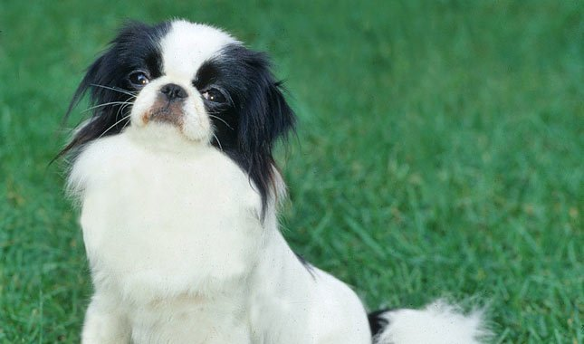

However, machine learning systems sort of need a lot of data to work with. Using a pre-trained network, exploiting the [super convergence effect](https://arxiv.org/pdf/1708.07120.pdf) and have lots of varied data, sometimes you only need 30 images. But that's still a lot of images, and normally, you need hundreds or thousands of images to really explore a completely new domain. Also, we as humans have lots of priors. We have lots of time to experience this world, and we are experts at that too, as we have evolution sets our weights to that of human values. So it's expected that we pick up on human tasks quite well. Our network, on the other hand, don't get to experience this prior, so we shouldn't really expect them to do much.

Also an interesting fact is that autistic children tend to struggle a lot with basic things that normal people take for granted, and takes quite a long time to learn them. More over, if you are a student of physics, you will find that classical mechanics is much easier to understand than quantum mechanics or relativity, because again, humans are evolved to view things the classical way as they exist on a relatively large scale compared to atoms and move relatively slowly compared to light.

No, to have a truely level playing field, we must find a task that we are not evolved for (so we can't use knowledge from evolution), but still requires complex thought and strategy development. Let's look at the game of Go. Let's quickly go over the rules:

```python
%%html
<iframe width="800" height="450" src="https://www.youtube.com/embed/WXuK6gekU1Y?start=465&end=502" frameborder="0" allow="accelerometer; autoplay; encrypted-media" allowfullscreen></iframe>
```

[video not shown]

Yeah, playing it seems difficult and humans are not evolved for that. How long does it take for an agent to beat the best human players? In DeepMind's [paper about AlphaZero](https://arxiv.org/pdf/1712.01815.pdf), they included a performance graph:

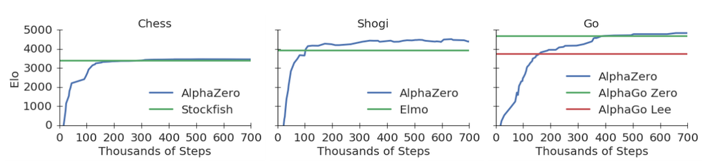

Green lines are the performance of existing top performing engines for chess and shogi. AlphaGo Lee is the nickname for the AlphaGo version that DeepMind actually used to beat Lee Sedol in the 2016 match, but was trained on amateur and professional matches initially. AlphaGo Zero is AlphaGo specifically trained from scratch on only the Go domain, and AlphaZero is the version that can be generalized to any perfect information game. AlphaGo Lee is slightly superhuman, as Lee Sedol actually managed to defeat 1 match out of 5. As we can see, AlphaZero managed to beat AlphaGo Lee's level after playing 150k matches.

How does human compare? Well, Hajin Lee, a member of the Korean Baduk Association (fun fact, "Baduk" is Korean for Go) who is sort of an ambassador for KBA and DeepMind and is the Secretary General of the International Go Federation, shares an insight into how many hours have been played by top level professionals:

```python
%%html
<iframe width="800" height="450" src="https://www.youtube.com/embed/0rDSnAbPbHY?start=686&end=901" frameborder="0" allow="autoplay; encrypted-media" allowfullscreen></iframe>
```

[video not shown]

19000 hours. Wow, that's serious dedication right there. Let's assume each Go match lasted 30 minutes (official tournaments are more like 2 hours though), so Hajin has played around $19k\cdot2=38k$ matches. But Hajin is just a 4 dan professional, while Lee Sedol is at 9 dan, the highest level one can achieve, so it's safe to say he has put in 2-3 times more hours than that, which brings the total number of matches played to 100k, which is pretty close to 150k matches of AlphaZero. I was surprised at this fact too, as I originally thought that humans use information a lot more efficient than our current intelligent systems.

Besides the domain of Go and more generally of games, I can't think of any other domains where humans are not evolved for, but still requires complex thought.

## Case study: AlexNet from 2012

Also, another interesting fact to consider is that the calculations with the human brain we previously talked about are only for a single forward pass. A backward pass (independent of time) is still needed to get the gradients, and only then can all of the training process continues. Let's consider a standard case for the ImageNet competition, where complex networks compete against each other to classify ImageNet's images. Let's take a closer look at the first time when CNNs look cool and the whole field was reignited, the [AlexNet network from 2012](https://papers.nips.cc/paper/4824-imagenet-classification-with-deep-convolutional-neural-networks.pdf).

Their architecture involves 2 parts of a network, each trained separately on a different GPU, but still have the capacity to talk to each other. The GPU they used is GTX 580 with 3GB. They trained for 6 days straight, cycles 90 times through the 1.2 million images of the ImageNet dataset, with a batch size of 128. Each cycle contains $\frac{1.2\cdot10^6}{128}=9375$ minibatches, so they train a total of $9375\cdot90=843750$ minibatches. Each minibatch contains a forward and backward pass, so the total number of equivalent forward passes is $843750\cdot2=1.6$ million. 6 days has $6\cdot24\cdot3600=518400$ seconds, so each forward pass took $\frac{518400}{1.6\cdot10^6}=0.3072$ seconds.

If we hope to be able to train full human brains at the iteration speed like AlexNet, then we need computing capability that is $\frac{500}{144}/0.3072=11.3$ times faster than today. Recall that 500 is the 500 teraflops human brains can calculate, and 144 is the teraflops Tesla's FSD computer can calculate. As computing capabilities doubles every 2 years, we have to wait $2\cdot log_2(11.3)=7$ more years from 2019 to reasonably experiment with training full scale human brains.

## What should we hope for in the future?

Computer performance will still be following the double exponential trend, and in the next 10 years, it seems like we can start to do actual experiments with brains. And as [Neuralink](https://www.youtube.com/watch?v=r-vbh3t7WVI) goes online, it seems like we can mess around with the fundamental nature of intelligence even more.

Already, there has been a bunch of interesting ideas and concepts, like the super convergence phenomenon I mentioned earlier. There are also ideas about getting rid of a lot of hyperparameters by just giving the network control over everything, including the learning rate, and works well right out of the box. Yet other people have found a way to generate good samples from a distribution without using a Generative Adversarial Network. Work with language models like GPT-2 seems promising too. All of these progress is quite exciting, and it seems like the field won't go into another AI winter this time around.